# Logistics Regression Class Exercise

Khalid Abdulshafi

Feb 8, 2022

> We will do a class exercise in Logistic Regression today. This will also become your submission for the day. We will do this work today in groups of two. Only one submission per team is needed - mention in comments (and in author field above) who all worked on it together.

# 1 Titanic Survival Model

We want to find out what factors affected passengers’ survival when Titanic sank. As survival is a binary measure, this task is well suited for a Logistic Regression analysis.

# 2 Task A: Load and Explore the Data

Training Data (data for building our model) is saved in the file `TitanicTrain.csv`

You should import TitanicTrain.csv data. Check the structure of the data using str() function. Note the following definitions

- `PClass`: Passenger Class
- `Sibsp`: Number of Siblings/Spouse aboard
- `Parch`: Number of Parents/Children aboard
- `Embarked`: Port of embarkation

Are there variables that are not in the right class? If yes then convert those variables to the correct class. For the purpose of the class exercise, we will keep things simple and not work with the following variables: `Name`, `Ticket` and `Cabin`. Delete these variables.

Are there `NA` values that we need to deal with?

```r
#Enter your code for loading, exploring and cleaning the data here.
titanic <- read.csv("TitanicTrain.csv")
```

```r
summary(titanic)
```

```
##   PassengerId       Survived          Pclass          Name
##  Min.   :  1.0   Min.   :0.0000   Min.   :1.000   Length:891
##  1st Qu.:223.5   1st Qu.:0.0000   1st Qu.:2.000   Class :character
##  Median :446.0   Median :0.0000   Median :3.000   Mode  :character
##  Mean   :446.0   Mean   :0.3838   Mean   :2.309
##  3rd Qu.:668.5   3rd Qu.:1.0000   3rd Qu.:3.000
##  Max.   :891.0   Max.   :1.0000   Max.   :3.000
##
##      Sex                 Age            SibSp           Parch
##  Length:891         Min.   : 0.42   Min.   :0.000   Min.   :0.0000
##  Class :character   1st Qu.:20.12   1st Qu.:0.000   1st Qu.:0.0000
##  Mode  :character   Median :28.00   Median :0.000   Median :0.0000
##                     Mean   :29.70   Mean   :0.523   Mean   :0.3816
##                     3rd Qu.:38.00   3rd Qu.:1.000   3rd Qu.:0.0000
##                     Max.   :80.00   Max.   :8.000   Max.   :6.0000
##                     NA's   :177
##     Ticket               Fare           Cabin             Embarked
##  Length:891         Min.   :  0.00   Length:891         Length:891
##  Class :character   1st Qu.:  7.91   Class :character   Class :character
##  Mode  :character   Median : 14.45   Mode  :character   Mode  :character
##                     Mean   : 32.20
##                     3rd Qu.: 31.00
##                     Max.   :512.33
##
```

```r
str(titanic)
```

```
## 'data.frame':    891 obs. of  12 variables:
##  $ PassengerId: int  1 2 3 4 5 6 7 8 9 10 ...
##  $ Survived   : int  0 1 1 1 0 0 0 0 1 1 ...
##  $ Pclass     : int  3 1 3 1 3 3 1 3 3 2 ...
##  $ Name       : chr  "Braund, Mr. Owen Harris" "Cumings, Mrs. John Bradley (Florence Briggs Thayer)" "Heikkinen, Miss. Laina" "Futrelle, Mrs. Jacques Heath (Lily May Peel)" ...
##  $ Sex        : chr  "male" "female" "female" "female" ...
##  $ Age        : num  22 38 26 35 35 NA 54 2 27 14 ...
##  $ SibSp      : int  1 1 0 1 0 0 0 3 0 1 ...
##  $ Parch      : int  0 0 0 0 0 0 0 1 2 0 ...
##  $ Ticket     : chr  "A/5 21171" "PC 17599" "STON/O2. 3101282" "113803" ...
##  $ Fare       : num  7.25 71.28 7.92 53.1 8.05 ...
##  $ Cabin      : chr  "" "C85" "" "C123" ...
##  $ Embarked   : chr  "S" "C" "S" "S" ...
```

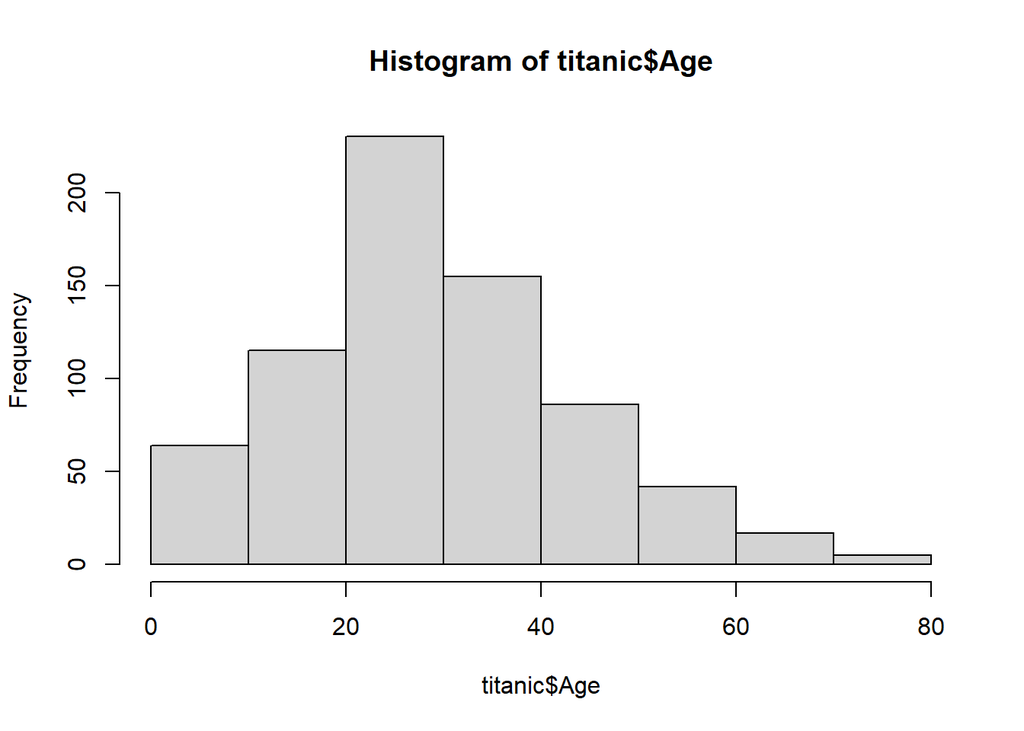

```r
#Cleaning
titanic$PassengerId <- NULL
titanic$Name <- NULL
titanic$Ticket <- NULL
titanic$Cabin <- NULL

#NA
titanic[titanic == "NA"] <- NA

#Factoring
titanic$Pclass = as.factor(titanic$Pclass)
titanic$Sex = as.factor(titanic$Sex)
titanic$Embarked = as.factor(titanic$Embarked)

hist(titanic$Age)
```

```r
#The distribution is skewed right, so replace any NA values with the median.

replace_NA = function(column, replace) {
  return(ifelse(is.na(column), replace(column, na.rm = TRUE), column))
}

titanic$Age = replace_NA(titanic$Age, median)

str(titanic)
```

```
## 'data.frame':    891 obs. of  8 variables:
##  $ Survived: int  0 1 1 1 0 0 0 0 1 1 ...
##  $ Pclass  : Factor w/ 3 levels "1","2","3": 3 1 3 1 3 3 1 3 3 2 ...
##  $ Sex     : Factor w/ 2 levels "female","male": 2 1 1 1 2 2 2 2 1 1 ...
##  $ Age     : num  22 38 26 35 35 28 54 2 27 14 ...
##  $ SibSp   : int  1 1 0 1 0 0 0 3 0 1 ...
##  $ Parch   : int  0 0 0 0 0 0 0 1 2 0 ...
##  $ Fare    : num  7.25 71.28 7.92 53.1 8.05 ...
##  $ Embarked: Factor w/ 4 levels "","C","Q","S": 4 2 4 4 4 3 4 4 4 2 ...
```

```r
summary(titanic)
```

```
##     Survived      Pclass      Sex           Age            SibSp
##  Min.   :0.0000   1:216   female:314   Min.   : 0.42   Min.   :0.000
##  1st Qu.:0.0000   2:184   male  :577   1st Qu.:22.00   1st Qu.:0.000
##  Median :0.0000   3:491                Median :28.00   Median :0.000
##  Mean   :0.3838                        Mean   :29.36   Mean   :0.523
##  3rd Qu.:1.0000                        3rd Qu.:35.00   3rd Qu.:1.000
##  Max.   :1.0000                        Max.   :80.00   Max.   :8.000
##      Parch             Fare        Embarked
##  Min.   :0.0000   Min.   :  0.00    :  2
##  1st Qu.:0.0000   1st Qu.:  7.91   C:168
##  Median :0.0000   Median : 14.45   Q: 77
##  Mean   :0.3816   Mean   : 32.20   S:644
##  3rd Qu.:0.0000   3rd Qu.: 31.00
##  Max.   :6.0000   Max.   :512.33
```

# 3 Task B: Build Our Model

Build a logistic regression model with `Survival` as the response variable. In this section, let’s first build a main effects model. What variables do you need to include as the predictor variables?

```r
#Enter your code for your logistic regression model here.
initial_model = glm(Survived ~ ., data = titanic, family = "binomial")
summary(initial_model)
```

```
##
## Call:
## glm(formula = Survived ~ ., family = "binomial", data = titanic)
##
## Deviance Residuals:
##     Min       1Q   Median       3Q      Max
## -2.6169  -0.6094  -0.4177   0.6109   2.4527
##
## Coefficients:
##               Estimate Std. Error z value Pr(>|z|)
## (Intercept)  16.380646 610.882145   0.027  0.97861
## Pclass2      -0.911903   0.297391  -3.066  0.00217 **
## Pclass3      -2.144097   0.297668  -7.203 5.89e-13 ***
## Sexmale      -2.710309   0.201224 -13.469  < 2e-16 ***
## Age          -0.038752   0.007873  -4.922 8.55e-07 ***
## SibSp        -0.320495   0.109056  -2.939  0.00329 **
## Parch        -0.091313   0.118850  -0.768  0.44231
## Fare          0.002304   0.002462   0.936  0.34940
## EmbarkedC   -12.318160 610.882033  -0.020  0.98391
## EmbarkedQ   -12.375887 610.882085  -0.020  0.98384
## EmbarkedS   -12.758300 610.882020  -0.021  0.98334
## ---
## Signif. codes:  0 '***' 0.001 '**' 0.01 '*' 0.05 '.' 0.1 ' ' 1
##
## (Dispersion parameter for binomial family taken to be 1)
##
##     Null deviance: 1186.66  on 890  degrees of freedom
## Residual deviance:  784.42  on 880  degrees of freedom
## AIC: 806.42
##
## Number of Fisher Scoring iterations: 13
```

Builging a model is always only the first step. The more important task is **interpreting** the model - what insights does your model give you?

> By creating a logistical regression model with respects to all variables provided, we discovered that although some variables such as passenger class, sex, age and number of siblings/spouse appeared to be statistically significant (all of which had P-values < 0.05), other variables appeared to have less statistically significant impacts.

# 4 Task C: Improve Our Model

How can we improve our model. There are several things you can try:

- Do we need any interaction effects?
- Do any of the variables have non-linear effects - should we include them in the model as a square term?

## 4.1 Interaction A: Sex and Age

```r
age_sex_interaction_model <- glm(Survived ~ Sex*Age, data=titanic, family = "binomial")
summary(age_sex_interaction_model)
```

```
##
## Call:
## glm(formula = Survived ~ Sex * Age, family = "binomial", data = titanic)
##
## Deviance Residuals:
##     Min       1Q   Median       3Q      Max
## -1.8985  -0.6695  -0.5989   0.7673   2.2903
##
## Coefficients:
##             Estimate Std. Error z value Pr(>|z|)
## (Intercept)  0.54145    0.30282   1.788 0.073771 .
## Sexmale     -1.37741    0.40414  -3.408 0.000654 ***
## Age          0.01895    0.01035   1.832 0.067023 .
## Sexmale:Age -0.04035    0.01356  -2.974 0.002936 **
## ---
## Signif. codes:  0 '***' 0.001 '**' 0.01 '*' 0.05 '.' 0.1 ' ' 1
##
## (Dispersion parameter for binomial family taken to be 1)
##
##     Null deviance: 1186.66  on 890  degrees of freedom
## Residual deviance:  908.09  on 887  degrees of freedom
## AIC: 916.09
##
## Number of Fisher Scoring iterations: 4
```

```r
#define new observation
new_sex_age_data <- data.frame(Sex="female", Age = 28)
new_sex_age_data2 <- data.frame(Sex="male", Age = 28)
new_sex_age_data3 <- data.frame(Sex="female", Age = 38)
new_sex_age_data4 <- data.frame(Sex="female", Age = 48)
new_sex_age_data5 <- data.frame(Sex="female", Age = 58)
new_sex_age_data6 <- data.frame(Sex="female", Age = 68)
new_sex_age_data7 <- data.frame(Sex="male", Age = 38)

#use model to predict value of survival
predict(age_sex_interaction_model, new_sex_age_data, type="response")
```

```
##         1
## 0.7450065
```

```r
predict(age_sex_interaction_model, new_sex_age_data2, type="response")
```

```
##         1
## 0.1923324
```

```r
predict(age_sex_interaction_model, new_sex_age_data3, type="response")
```

```
##         1
## 0.7793176
```

```r
predict(age_sex_interaction_model, new_sex_age_data4, type="response")
```

```
##         1
## 0.8101881
```

```r
predict(age_sex_interaction_model, new_sex_age_data5, type="response")
```

```
##       1
## 0.83764
```

```r
predict(age_sex_interaction_model, new_sex_age_data6, type="response")
```

```
##         1
## 0.8617988
```

```r
predict(age_sex_interaction_model, new_sex_age_data7, type="response")
```

```
##         1
## 0.1612659
```

[output not shown]

## 4.2 Interaction B: Sex and Siblings

```r
# interactions between sex and age
sex_siblings_interaction_model = glm(Survived ~ Sex*SibSp, data=titanic, family = "binomial")
summary(sex_siblings_interaction_model)
```

```
##
## Call:
## glm(formula = Survived ~ Sex * SibSp, family = "binomial", data = titanic)
##
## Deviance Residuals:
##     Min       1Q   Median       3Q      Max
## -1.8194  -0.6534  -0.6382   0.6512   1.9086
##
## Coefficients:
##               Estimate Std. Error z value Pr(>|z|)
## (Intercept)     1.4430     0.1660   8.692  < 2e-16 ***
## Sexmale        -2.8786     0.2017 -14.271  < 2e-16 ***
## SibSp          -0.4991     0.1251  -3.989 6.63e-05 ***
## Sexmale:SibSp   0.4467     0.1652   2.704  0.00685 **
## ---
## Signif. codes:  0 '***' 0.001 '**' 0.01 '*' 0.05 '.' 0.1 ' ' 1
##
## (Dispersion parameter for binomial family taken to be 1)
##
##     Null deviance: 1186.66  on 890  degrees of freedom
## Residual deviance:  897.71  on 887  degrees of freedom
## AIC: 905.71
##
## Number of Fisher Scoring iterations: 4
```

```r
#define new observation
new_sex_siblings_data <- data.frame(Sex="female", SibSp = 0)
new_sex_siblings_data2 <- data.frame(Sex="male", SibSp = 0)
new_sex_siblings_data3 <- data.frame(Sex="female", SibSp = 1)
new_sex_siblings_data4 <- data.frame(Sex="male", SibSp = 1)


#use model to predict value of survival
predict(sex_siblings_interaction_model, new_sex_siblings_data, type="response")
```

```
##         1
## 0.8089192
```

```r
predict(sex_siblings_interaction_model, new_sex_siblings_data2, type="response")
```

```
##        1
## 0.192233
```

```r
predict(sex_siblings_interaction_model, new_sex_siblings_data3, type="response")
```

```
##         1
## 0.7198897
```

```r
predict(sex_siblings_interaction_model, new_sex_siblings_data4, type="response")
```

```
##         1
## 0.1842346
```

[output not shown]

## 4.3 Interaction C: Sex and Children

```r
sex_children_interaction_model = glm(Survived ~ Sex*Parch, data=titanic, family = "binomial")
summary(sex_children_interaction_model)
```

```
##
## Call:
## glm(formula = Survived ~ Sex * Parch, family = "binomial", data = titanic)
##
## Deviance Residuals:
##     Min       1Q   Median       3Q      Max
## -1.7972  -0.6204  -0.6204   0.6660   1.8668
##
## Coefficients:
##               Estimate Std. Error z value Pr(>|z|)
## (Intercept)     1.3931     0.1646   8.462  < 2e-16 ***
## Sexmale        -2.9432     0.2017 -14.589  < 2e-16 ***
## Parch          -0.4558     0.1234  -3.694 0.000221 ***
## Sexmale:Parch   0.7949     0.1949   4.078 4.54e-05 ***
## ---
## Signif. codes:  0 '***' 0.001 '**' 0.01 '*' 0.05 '.' 0.1 ' ' 1
##
## (Dispersion parameter for binomial family taken to be 1)
##
##     Null deviance: 1186.66  on 890  degrees of freedom
## Residual deviance:  898.68  on 887  degrees of freedom
## AIC: 906.68
##
## Number of Fisher Scoring iterations: 4
```

```r
#define new observation
new_sex_children_data <- data.frame(Sex="female", Parch = 0)
new_sex_children_data2 <- data.frame(Sex="male", Parch = 0)
new_sex_children_data3 <- data.frame(Sex="female", Parch = 1)
new_sex_children_data4 <- data.frame(Sex="male", Parch = 1)


#use model to predict value of survival
predict(sex_children_interaction_model, new_sex_children_data, type="response")
```

```
##        1
## 0.801086
```

```r
predict(sex_children_interaction_model, new_sex_children_data2, type="response")
```

```
##         1
## 0.1750754
```

```r
predict(sex_children_interaction_model, new_sex_children_data3, type="response")
```

```
##         1
## 0.7185541
```

```r
predict(sex_children_interaction_model, new_sex_children_data4, type="response")
```

```
##         1
## 0.2295314
```

[output not shown]

## 4.4 Interaction D: Sex and Class

```r
sex_class_interaction_model <- glm(Survived ~ Sex*Pclass, data=titanic, family = "binomial")
summary(sex_class_interaction_model)
```

```
##
## Call:
## glm(formula = Survived ~ Sex * Pclass, family = "binomial", data = titanic)
##
## Deviance Residuals:
##     Min       1Q   Median       3Q      Max
## -2.6248  -0.5853  -0.5395   0.4056   1.9996
##
## Coefficients:
##                 Estimate Std. Error z value Pr(>|z|)
## (Intercept)       3.4122     0.5868   5.815 6.06e-09 ***
## Sexmale          -3.9494     0.6161  -6.411 1.45e-10 ***
## Pclass2          -0.9555     0.7248  -1.318  0.18737
## Pclass3          -3.4122     0.6100  -5.594 2.22e-08 ***
## Sexmale:Pclass2  -0.1850     0.7939  -0.233  0.81575
## Sexmale:Pclass3   2.0958     0.6572   3.189  0.00143 **
## ---
## Signif. codes:  0 '***' 0.001 '**' 0.01 '*' 0.05 '.' 0.1 ' ' 1
##
## (Dispersion parameter for binomial family taken to be 1)
##
##     Null deviance: 1186.7  on 890  degrees of freedom
## Residual deviance:  798.1  on 885  degrees of freedom
## AIC: 810.1
##
## Number of Fisher Scoring iterations: 6
```

```r
# Scenario #1: female, Pclass1
new_sex_class_data <- data.frame(Sex="female", Pclass = "1")
predict(sex_class_interaction_model, new_sex_class_data, type="response")
```

```
##         1
## 0.9680851
```

```r
# Scenario #2: female, Pclass2
new_sex_class_data2 <- data.frame(Sex="female", Pclass = "2")
predict(sex_class_interaction_model, new_sex_class_data2, type="response")
```

```
##         1
## 0.9210526
```

```r
# Scenario #3: female, Pclass3
new_sex_class_data3 <- data.frame(Sex="female", Pclass = "3")
predict(sex_class_interaction_model, new_sex_class_data3, type="response")
```

```
##   1
## 0.5
```

```r
# Scenario #4: male, Pclass1
new_sex_class_data4 <- data.frame(Sex="male", Pclass = "1")
predict(sex_class_interaction_model, new_sex_class_data4, type="response")
```

```
##         1
## 0.3688525
```

```r
# Scenario #5: male, Pclass2
new_sex_class_data5 <- data.frame(Sex="male", Pclass = "2")
predict(sex_class_interaction_model, new_sex_class_data5, type="response")
```

```
##         1
## 0.1574074
```

```r
# Scenario #6: male, Pclass3
new_sex_class_data6 <- data.frame(Sex="male", Pclass = "3")
predict(sex_class_interaction_model, new_sex_class_data6, type="response")
```

```
##         1
## 0.1354467
```

```
Explanation:

For both females and males, the lower the class, the lower the likelihood of survival. In every passenger class, females are more likely to survive than men. Interestingly, a female in 3rd class is more likely to survive than a male in first class.
```

What is your best model? Explain your best model - what are you seeing as significant? What is the interpretation? What does it mean?

[output not shown]

# 5 Task D: Predict Outcomes in Testing Data

> We will likely not be able to do this during the class exercise. This task is for you to do on your own after the class.

We have saved a small part of data to test our model. This is the **Testing Data**. We will use this data to see how good of a prediction is made by the model we created in Task D above.

You should do the following:

- Import the testing data in `TitanicTest.csv`
- Check that you have all the predictor variables. It will natually not have the response variable
- Do any variable need recoding to match the training dataset? If yes then do the necessary variable recoding
- Predict the Survival Probability for the Testing Dataset using the model developed on the training dataset in Step C above. Use the `predict` command.
- Convert probabilities to a a binary outcome (1 for Prob > 0.5, otherwise 0 - or choose your own threshold; this will need an `ifelse` statement)

```r
#Enter your code for predicting outcomes in testing data here.
test <- read.csv("TitanicTest.csv")

#Cleaning
# test$PassengerId <- NULL
test$Name <- NULL
test$Ticket <- NULL
test$Cabin <- NULL

#NA
test[test == "NA"] <- NA

#Factoring
test$Pclass = as.factor(test$Pclass)
test$Sex = as.factor(test$Sex)
test$Embarked = as.factor(test$Embarked)

replace_NA = function(column, replace) {
  return(ifelse(is.na(column), replace(column, na.rm = TRUE), column))
}

test$Age = replace_NA(test$Age, median)
```

```r
test$Survived <- ifelse(round(predict(initial_model, test, type="response")) == 0, 0, 1)
```

```r
#Remove all columns except for PassengerId and Survived
test[ , 2:8] <- list(NULL)
```

```r
#Export dataframe to csv
write.csv(test,"C:/Users/kabdu/Documents/Winter 2022/TO 414 001 WN 2022/HW #3\\titanic_test_kaggle_submission.csv", row.names = FALSE)
```

# 6 Task E: Compete with Rest of the World

What you just did happens to be one of the ongoing competitions at kaggle.com. https://www.kaggle.com/c/titanic has more details. Once you have predicted outcomes on the test data, you need to create a submission file that has two columns: “PasserngerID” and “Survived”. The second column should have 1 or 0 for survived or not. NA or missing values in this field is not permitted. Create an account at kaggle and upload your solution at https://www.kaggle.com/c/titanic/submit

Kaggle will evaluate your submission and let you know

1. What is your score (how good is your prediction)
2. What is your rank among all submissions

```
Enter here the following:
1. Your Kaggle Username: khalidabdulshafi
2. Your Kaggle Rank: 10590
3. What did you learn in this exercise? Summarize your experience. What can you do better given more time? I learned how to apply a logistic regression model to predict a categorical dependent variable. In this case, I was able to predict survival of passengers of the Titanic with a 76.5% accuracy. Given more time, I can build a better model, and I can land higher up on the leaderboard.
```

> When you are done, submit you files (RMD and HTML) to Canvas for our class exercise. Lets see who in class gets the best rank on Kaggle. **There will be a surprise prize for the best submission!**